# Data

Introduction to Data Science with R [www.therbootcamp.com](https://therbootcamp.github.io) [@therbootcamp](https://twitter.com/therbootcamp)

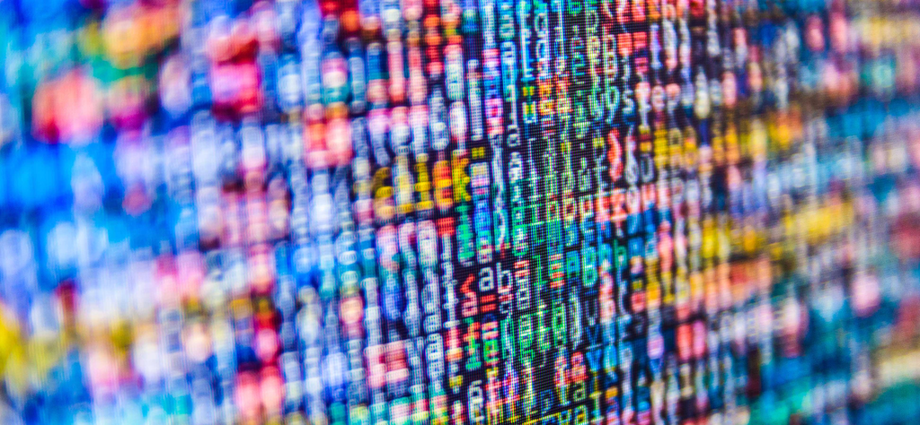

[source](https://www.methodspace.com)

### Overview

In this practical you’ll learn how to work with basic data objects and functions. By the end of this practical you will know how to:

1. Create vectors of different types using `c()`
2. Understand the three main vector classes numeric, character, and logical using `class()`
3. Calculate basic descriptive statistics using `mean()`, `median()`, `table()` (and more!)
4. Read and write data of various data formats using `read_csv()` and others
5. Access and change vectors from data frames using `$`
6. Create `data.frames` and `tibbles`! using `data.frame()` and `tibble()`

### Datasets

| File | Rows | Columns | Description |
| --- | --- | --- | --- |
| diamonds.csv | 100 | 7 | Subset of the well-known diamonds data set containing specifications and prices of a large number of recorded diamonds. |
| titanic.xls | 1309 | 14 | Information on the survival of titanic passengers. |
| sleep.sav | 271 | 55 | Survey on sleeping behavior completed by staff at the University of Melbourne. |
| airbnb_zuerich.sas7bdat | 2392 | 20 | Data on AirBnB listings in Zürich, Switzerland |

### Packages

| Package | Installation |
| --- | --- |
| `tidyverse` | `install.packages("tidyverse")` |
| `readr` | `install.packages("readr")` |
| `haven` | `install.packages("haven")` |
| `readxl` | `install.packages("readxl")` |

### Glossary

*Creating vectors*

| Function | Description |
| --- | --- |
| `c("a", "b", "c")` | Create a character vector |
| `c(1, 2, 3)` | Create a numeric vector |
| `c(TRUE, FALSE, TRUE)` | Create a logical vector |

*Vector functions*

| Function | Description |
| --- | --- |
| `mean(x), median(x), sd(x), sum(x)` | Mean, median standard deviation, sum |
| `max(x), min(x)` | Maximum, minimum |
| `table(x)` | Table of frequency counts |
| `round(x, digits)` | Round a numeric vector x to `digits` |

*Accessing vectors from data frames*

| Function | Description |
| --- | --- |
| `df$name` | Access vector `name` from a data frame `df` |

*Reading/writing text data*

| Extension | File Type | Read | Write |
| --- | --- | --- | --- |
| `.csv` | Comma-separated text | `read_csv(file)` | `write_csv(x, file)` |
| `.csv` | Semi-colon separated text | `read_csv2(file)` | *not available* |
| `.txt` | Other text | `read_delim(file)` | `write_delim(x, file)` |

*Reading/writing other data formats*

| Extension | File Type | Read | Write |
| --- | --- | --- | --- |
| `.xls`, `.xlsx` | Excel | `read_excel(file)` | `xlsx::write.xlsx()` |
| `.sav` | SPSS | `read_spss(file)` | `write_spss(x, file)` |
| `.sas7bdat` | SAS | `read_sas(file)` | `write_sas(x, file)` |

*Creating data frames from vectors*

| Function | Description |
| --- | --- |
| `data.frame(a, b, c)` | Create a data frame from vectors a, b, c |
| `tibble(a, b, c)` | Create a tibble from vectors a, b, c |

### Examples

```r
library(tidyverse)
library(readr)
library(readxl)
library(haven)

# Create vectors of (fake) stock data
name      <- c("apple", "microsoft", "dell", "google", "twitter")
yesterday <- c(100, 89, 65, 54, 89)
today     <- c(102, 85, 72, 60, 95)

# Summary statistics
mean(today)
mean(yesterday)

# Show classes
class(name)
class(yesterday)

# Operations of vectors
change <- today - yesterday
change # Print result

# Create a logical vector from two numerics
increase <- today > yesterday
increase # Print result

# Create a tibble combining multiple vectors
stocks <- tibble(name, yesterday, today, change, increase)

# Get column names
names(stocks)

# Access columns by name
stocks$name
stocks$today

# Calculate descriptives on columns
mean(stocks$yesterday)
median(stocks$today)
table(stocks$increase)
max(stocks$increase)


# read/write delim-separated -------------------

# read chickens data
chickens <- read_csv(file = "1_Data/chickens.csv")

# fix header of chickens_nohead.csv with known column names
chickens <- read_csv(file = "1_Data/chickens_nohead.csv",
                     col_names = c("weight", "time", "chick", "diet"))

# fix NA values of chickens_na.csv
chickens <- read_csv(file = "1_Data/chickens_na.csv",
                     na = c('NA', 'NULL'))

# write clean data to disc
write_csv(x = chickens,
          path = "1_Data/chickens_clean.csv")

# fix types -------------------
# Note: the survey data is fictional!

# remove character from rating
survey$rating[survey$rating == "2,1"] <- 2.1

# rerun type convert
survey <- type_convert(survey)

# other formats -------------------

# .xlsx (Excel)
chickens <- read_excel("1_Data/chickens.xlsx")

# .sav (SPSS)
chickens <- read_spss("1_Data/chickens.sav")

# .sad7bdata (SAS)
chickens <- read_sas("1_Data/chickens.sas7bdat")
```

# Tasks

## A - Getting setup

1. Open your `baselrbootcamp` R project. It should already have the folders `1_Data` and `2_Code`.
2. Open a new R script and save it as a new file called `data_practical.R` in the `2_Code` folder. At the top of the script, using comments, write your name and the date. Then, load all package(s) listed in the Packages section above with `library()`. Make sure that each of the datasets listed above lie in your `1_Data` folder.

## B - Creating vectors

The table below shows results from a (fictional) survey of 10 Baselers. In the first part of this practical, you will convert this table to R objects and then analyse them!

| id | sex | age | height | weight |
| --- | --- | --- | --- | --- |
| 1 | male | 44 | 174.3 | 113.4 |
| 2 | male | 65 | 180.3 | 75.2 |
| 3 | female | 31 | 168.3 | 55.5 |
| 4 | male | 27 | 209 | 93.8 |
| 5 | male | 24 | 176.7 |  |
| 6 | male | 63 | 186.6 | 67.4 |
| 7 | male | 71 | 151.6 | 83.3 |
| 8 | female | 41 | 155.7 | 67.8 |
| 9 | male | 43 | 176.1 | 69.3 |
| 10 | female | 31 | 166.1 | 66.3 |

1. Create a numeric vector called `id` that shows the id values. When you finish, print the vector object to see it!

```r
# Create a vector id
XX <- c(XX, XX, ...)

# Print the vector id
XX
```

2. Using the `class()` function, check the class of your `id` vector. Is it `"numeric"`?

```r
# Show the class of an object XX
class(XX)
```

3. Using the `length()` function, find out the length of your `id` vector. Does it have length 10? If not, make sure you defined it correctly!

```r
# Show the length of the id vector
length(XX)
```

4. Create a character vector called `sex` that shows the sex values. Make sure to use quotation marks “” to enclose each element to tell R that the data are of type `"character"`! When you finish, print the object to see it!

```r
# Create a character vector sex
XX <- c("XX", "XX", "...")
```

5. Using the `class()` function, check the class of your `sex` vector. Is it `"character"`?
6. Using the `length()` function, find out the length of your `sex` object. Does it have length 10? If not, make sure you defined it correctly!
7. Using the same steps as before, create a `age` and `height` vector.
8. Look at the weight data, you’ll notice it contains an missing value. Create a vector called `weight` containing these data, following the same steps as before, making sure to specify the missing value as `NA` (no quotation marks).

## C - Functions

1. Using the `table()` function, find out how many males and females are in the data. You should find 7 males and 3 females!
2. Using the `mean()` function, calculate the mean `age`. It should be 44!
3. Try calculating the mean value of `sex`. What happens? Why?
4. Try calculating the mean `weight`. You should get an `NA` value. Why?
5. Look at the help menu for the `mean()` function (using `?mean`) to look for an argument that will help you with your problem.
6. Using the correct argument for the mean function, calculate the mean weight ignoring `NA` values. It should be 76.89!

## D - Read & write delim-separated text files

In this section, you will read in a subset of the well known diamonds data set and prepare it for data analysis.

1. Identify the file path to the `diamonds.csv` dataset using the `""` (quotation marks) auto-complete trick. Place the cursor between two quotation marks, hit ⇥ (tab-key), and browse through the folders. Save the file path, for now, in an object called `diamonds_path`.

```r
# place cursor in-between "" and hit tab
diamonds_path <- ""
```

2. Now use the Using `diamonds_path` insdide the `read_csv()` function to read in the `diamonds.csv` dataset. Store it as a new object called `diamonds`.

```r
# read diamonds data
diamonds <- read_csv(file = XX)
```

3. Print the `diamonds` data and inspect the column names in the header line. Something’s wrong!
4. Fix the header by reading in the data again using the `col_names`-argument. Assign to `col_names` a character vector containing the correct column names: `carat`, `cut`, `color`, `clarity`, `depth`, `table`, `price`.

```r
# read diamonds data with specified col_names
diamonds <- read_csv(file = "XX",
                     col_names = c('name_1','name_2','...'))  # Vector of column names
```

5. Re-inspect the header by printing the data. Has the header been fixed?
6. Now pay attention to the classes of the individuals columns (variables). Have all classes been identified correctly? What about the `carat` column? It should be `numeric`, right?
7. Let’s see what went wrong. Select and print the `carat` variable to identify the one entry that caused the variable to become a `character` vector (Hint: look for a comma between entry 10 and 20).
8. Change the incorrectly formated entry in `carat` by replacing `XX` with the index of the incorrect value (i.e., the correct number between 10 and 20) and `YY` with the correct entry with a period (`.`) instead of a comma (`,`) in the code below.

```r
# Change the value at position XX to YY
diamonds$carat[XX] <- YY
```

9. Ok you fixed the value but `carat` is still `character`. We can fix it with the `type_convert()` function. Apply the `type_convert()` function to the `diamonds` data to have R fix all the data types. Make sure to assign the result back to `diamonds` so that you change the object!

```r
# re-infer data types
diamonds <- type_convert(diamonds)
```

10. Print the `diamonds` object and look at the column types. Has the type of `carat` changed to `double`?
11. Write the, now, properly formatted diamonds data to your data folder as a `.csv` file using the name `diamonds_clean.csv`. Don’t forget to include both the file name and the folder (separated by `/`) in the character string specifying the `path` argument.

```r
# write clean diamonds data to disc
write_csv(x = XX, path = "XX")
```

12. Read `diamonds_clean.csv` back into R as a new object called `diamonds_clean`. Then, print the object and verify that this time the types been correctly identified from the start.
13. The data is now ready for analysis. Explore it a bit by calculating a few statistics. For instance, what is the average `carat` or `price` (use `mean()`)? What `cut` and `clarity` levels exist and how often do they occur (use `table()` on both variables)? You can learn more about the variable values from the help file `?diamonds`.

## E - Logical Vectors and `$`

1. Logical vectors contain as values only `TRUE` and `FALSE` (and `NA`s). Create a new logical vector called `expensive` indicating which diamonds are more expensive than $10000. To do this, select the `price` variable from the data frame using `$` use the `>` (greater than) operator á la `vector > value`.

```r
# Create a logical vector expensive indicating
# which dimaonds cost more than 10,000

ZZ <- diamonds$XX > YY
```

2. Print your `expensive` vector to the console. Do you see only TRUE and FALSE values? If so, do the first few values match those in the `price` variable?
3. Add your `expensive` vector to the diamonds data frame using `data_frame$variable_name <- variable`. See below?

```r
# add vector to data frame
XX$YY <- ZZ
```

4. Using the `table()` function, create a table showing how many of the diamonds are expensive how many are not. Select the variable directly from the data frame using `$`.
5. Using the `mean()` function, determine the percentage of the diamonds that are expensive, i.e., `mean(expensive)`. Should this have worked?
6. What percent diamonds weigh more than 1 `carat` (i.e., more than .2 gram)?

## F - Read other file formats

#### Excel

[figure not shown]

1. Using `read_excel()`, read in the `titanic.xls` dataset as a new object called `titanic` (Make sure you have alredy loaded the `readxl` package at the beginning of your script).

```r
titanic <- read_excel(path = "XX")
```

2. Print `titanic` and evaluate its dimensions using `dim()`.
3. Using `table()`, how many people survived (variable `survived`) in each cabin class (variable `pclass`)?

```r
# determine survival rate by cabin class
table(titanic$XX,
      titanic$XX)
```

4. Using `write_csv()`, write the `titanic` dataframe as a new comma separated text file called `titanic.csv` in your `1_Data` folder. Now you have the data saved as a text file any software can use!

#### SPSS

[figure not shown]

5. Using `read_spss()` read in the sleep data set `sleep.sav` of staff at he University of Melbourne as a new object called `sleep`. (Make sure that you have first loaded the `haven` package).

```r
XX <- read_spss(file = "XX")
```

6. Print your `sleep` object and evaluate its dimensions using `dim()`.
7. How many drinks do staff at the University of Melbourne consumer per day (variable `alcohol`). To do this, use the `mean()` function, while taking care of missing values using the `na.rm` argument.
8. Using the `write_csv()` function, write the `sleep` data to a new file called `sleep.csv` in your `1_Data` folder. Now you have the `sleep` data stored as a text file any software can use!

#### SAS

[figure not shown]

9. Using `read_sas()`, read in `airbnb_zuerich.sas7bdat` containing AirBnB listings in Zürich, Switzerland and call the object `airbnb_zuerich`.

```r
# read sas data
XX <- read_sas(data_file = "XX")
```

10. Print `airbnb_zuerich` and then evaluate its dimensions using `dim()`.
11. How many AirBnB listings were there of each `room_type` in Zürich? (Hint: use `table()`)
12. Using `write_csv()` write your `airbnb_zuerich` data frame to as new comma-separated text file called `airbnb_zuerich.csv` in your `1_Data` folder.

## G - Creating data frames

```r
# Create data frame ten_df containing vectors id, age, sex, height, weight, and tall_180
XX <- data.frame(XX, XX, XX, XX, XX, XX)
```

[output not shown]

## X - Challenges

1. If you take the `sum()` of a logical vector, R will return the number of cases that are `TRUE`. Using this, find out how many of the ten Baselers are male while using the is-equal-to operator `==`.

```r
# Determine the frequency of a case in a vector
sum(XX == XX)
```

2. You can use logical vectors to select rows from a data frame based on certain criteria. using the following template, get the id values of Baselers who are younger than 30:

```r
# Create a logical vector indicating which baselers are younger than 30
young_30 <- XX$XX < 30

# Print the ids of baselers younger than 30
XX$XX[young_30]
```

3. Use a combination of logical vectors and the `mean()` function to answer the question: “What is the mean age of Baselers who are heavier than 80kg?”
4. What are the id values of Baselers who are male *and* are shorter than 165cm? (Hint: You will need to use the logical AND operator `&` to combine multiple logical vectors)

## Additional Resources

- For more information on the fundamentals of object and functions in R see the R Core team’s [introduction to R](https://cran.r-project.org/doc/manuals/r-release/R-intro.html) and for even more advanced object and function-related topics Hadley Wickham’s [Advanced R](http://adv-r.had.co.nz/).
- For more information on reading and writing (and everything else) see Grolemund`s and Wickham’s [R for Data Science](http://r4ds.had.co.nz/data-import.html).